# Sept. 2019 Mini Challenge

EKU R User Group

9/16/2019

## Challenge

Implement a jackknife procedure to produce a graphical display (such as a histogram or boxplot) of the $R^2$ value for the model estimating `weight` as a function of `Time`.

See [The Challege Description](https://ekuresearchanalysis.github.io/RUserGroup/MiniChallenge/2019-09/MiniChallenge) for details.

## Solution

First, let’s make an object to store the results of our jackknife. There are a number of ways we can do this. I will use the simplest here, and then demonstrate some other approaches at the end.

For the simplest approach, we can create a vector that has as many elements as the number of rows in the data set.

```r
n <- nrow(ChickWeight) # number of rows in data.
jack_knife_r_squared <- vector(mode = "numeric",
                               length = n)
```

Next, we write a `for` loop that will omit one observation from the data on each build of the model.

```r
for (i in seq_along(jack_knife_r_squared)){
  temp_fit <- lm(formula = weight ~ Time,
                 data = ChickWeight[-i, ])
  jack_knife_r_squared[i] <- summary(temp_fit)$adj.r.squared
}
```

With the results in the vector, we may use the `hist` command to produce a quick histogram.

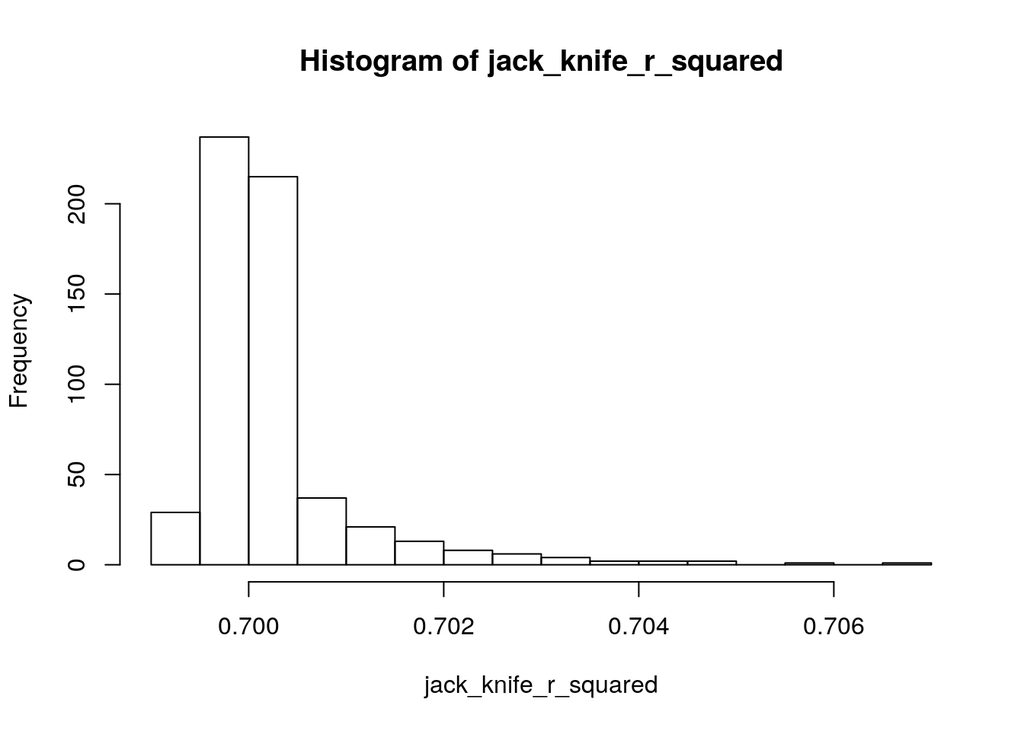

```r
hist(jack_knife_r_squared)
```

### A note about `seq_along`

When first learning to write R code, it can be tempting to write `for` loops with the form

```r
for (i in 1:length(vector_of_interest)){
  ...
}
```

This can occasionally lead to frustrating errors if, for some reason, `vector_of_interest` has length 0. This might happen if there were no valid results in a previous step of the analysis. When this occurs, the loop tries to iterate over `i = c(1, 0)` and causes an error.

Initiating loops using `seq_along` avoids this problem because `seq_along` will construct the approriate iteration sequence to skip the loop if `vector_of_interest` has length zero. Compare the differences below.

```r
vector_of_interest <- vector("numeric", length = 0)

1:length(vector_of_interest)
```

```
## [1] 1 0
```

```r
seq_along(vector_of_interest)
```

```
## integer(0)
```

It may not seem like much of an issue now, but debugging these kinds of errors can be time consuming and frustrating.

## Alternative Solutions

### Results back to the data

We may also approach the problem by putting the results directly into the data frame.

```r
ChickWeight$adj_r_sq_without_this_row <- rep(NA, length = nrow(ChickWeight))

for (i in seq_len(nrow(ChickWeight))){
  temp_fit <- lm(formula = weight ~ Time,
                 data = ChickWeight[-i, ])
  ChickWeight$adj_r_sq_without_this_row[i] <-
    summary(temp_fit)$adj.r.squared
}
```

This sets us up to use either the `hist` command or to use `ggplot` plotting tools. Differences in these plots are related to differences in how the two functions define the break points under their respective defaults.

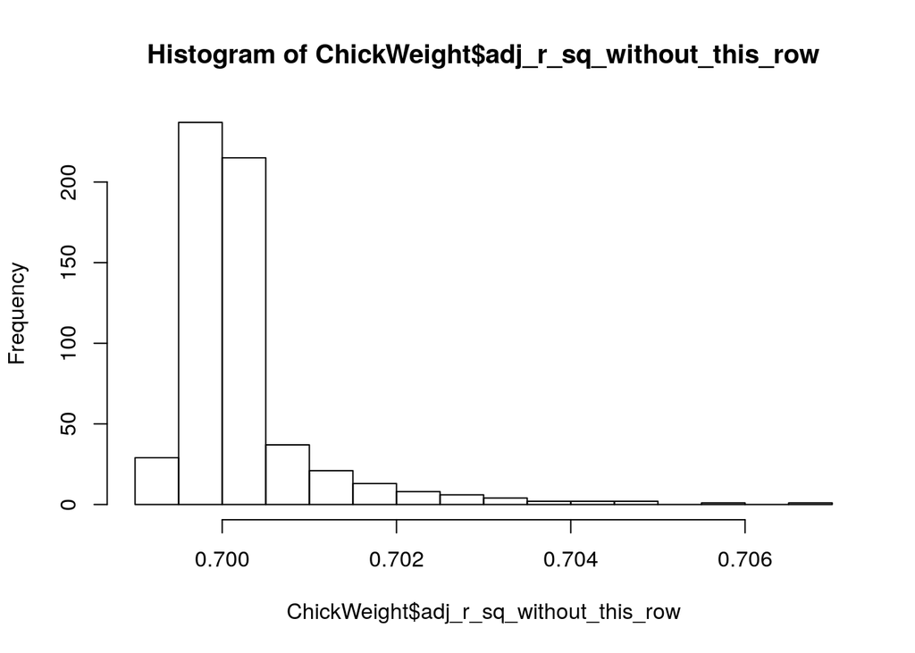

```r
hist(ChickWeight$adj_r_sq_without_this_row)

library(ggplot2)
```

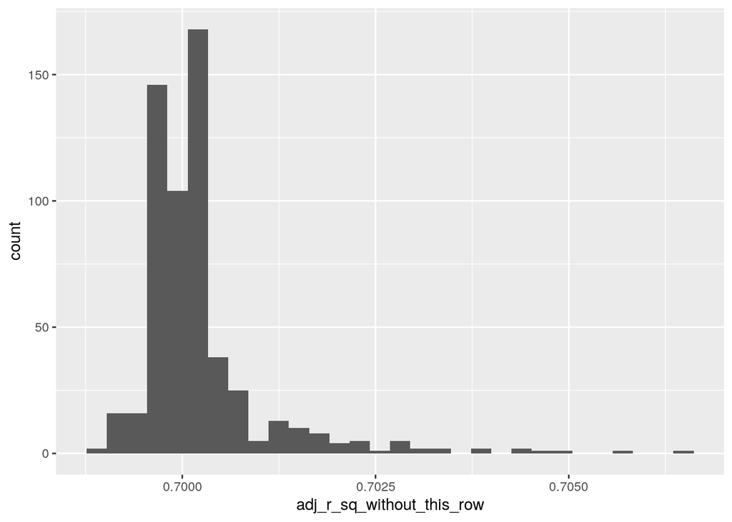

```r
ggplot(data = ChickWeight,
       mapping = aes(x = adj_r_sq_without_this_row)) +
  geom_histogram()
```

### `apply` functions

R features a family of functions that will *apply* a set of commands across a set of values. The functions perform all of the details of a `for` loop for you, while avoiding some of the traps that can trip you up when writing your own `for` loops. This requires having a function that will perform just one iteration of your loop.

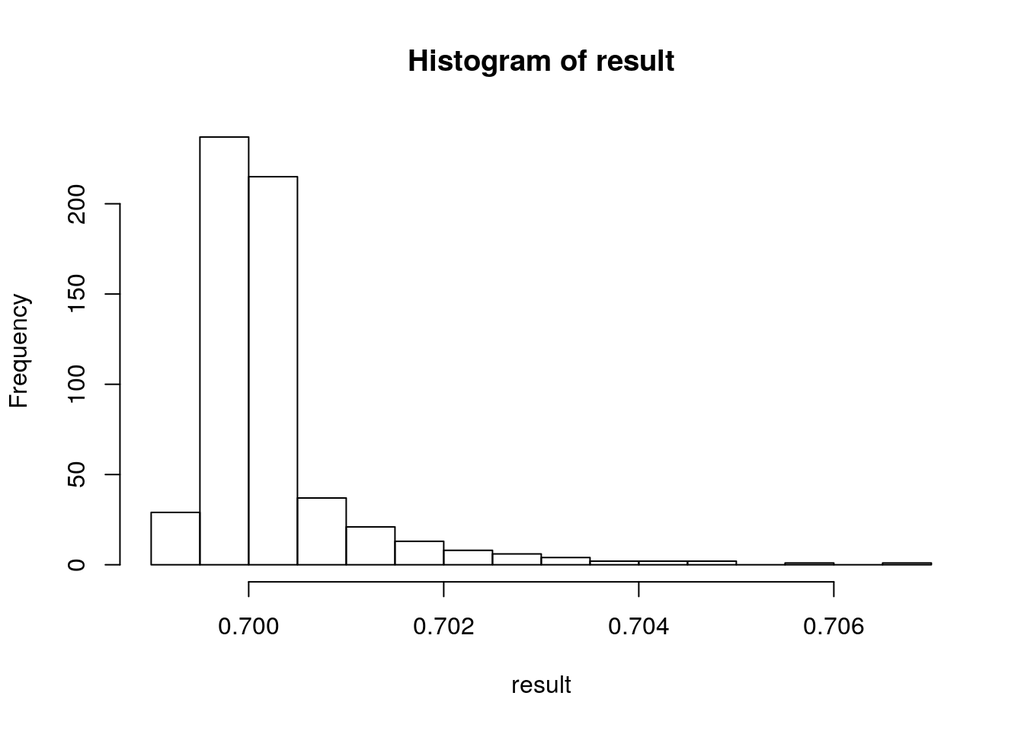

```r
jack_r_square <- function(row_to_omit){
  fit <- lm(formula = weight ~ Time,
                 data = ChickWeight[-row_to_omit, ])
  summary(fit)$adj.r.squared
}

result <- sapply(X = seq_len(nrow(ChickWeight)),
                 FUN = jack_r_square)

hist(result)
```